# 分布の違いを測る Measure dissimilarity between distributions KLダイバージェンス KL-divergence

ryamada

2017年3月6日

# 1 平坦と直線と直交 Flatness, straight lines and perpendicular

## 1.1 直線 Straigt lines

- $\theta,\eta$座標系はそれぞれ平坦座標系であるから、$\theta_i$一定、$\eta_j$一定の点(上図の４種類の線)は、「直線」である。Because both $\theta$ and $\eta$ coordinate systems are flat, points with same value of $\theta_i$ or $\eta_j$ are in “straight lines”, that are shown in the figure above with 4 colors.
- $\theta_1,\theta_2$の線形和で表される線も「直線」。$\eta_1,\eta_2$の線形和で表される線も「直線｣。Points that are expressed as linear sum of $\theta_1$ and $\theta_2$ are in “straight lines” as well. Same for $\eta_1$ and $eta_2$.

## 1.2 直交

- $\theta$座標系と$\eta$座標系は双直交であるから、$\theta_1$と$eta_2$は直交し、$\theta_2$と$eta_1$は直交する。 Because two coordinate systems are in dual orthogonal relataion, $\theta_1$ and $\eta_2$ are perpendicular and $\theta_2$ and $\eta_1$ are perpendicular.

## 1.3 例 Example

- 以下の図は、正規分布の$\theta$座標系格子と$\eta$座標系格子とを、$(m,s)$座標系に描いたものである。The figure below is drawn as its x and y axes are m and s and $\theta$-lattice and $\eta$-lattice are drawn in it.
- 赤線は$\theta_1$一定の点を描いたもの、同様に、緑は$\theta_2$、青は$\eta_1$、水色は$\eta_2$。

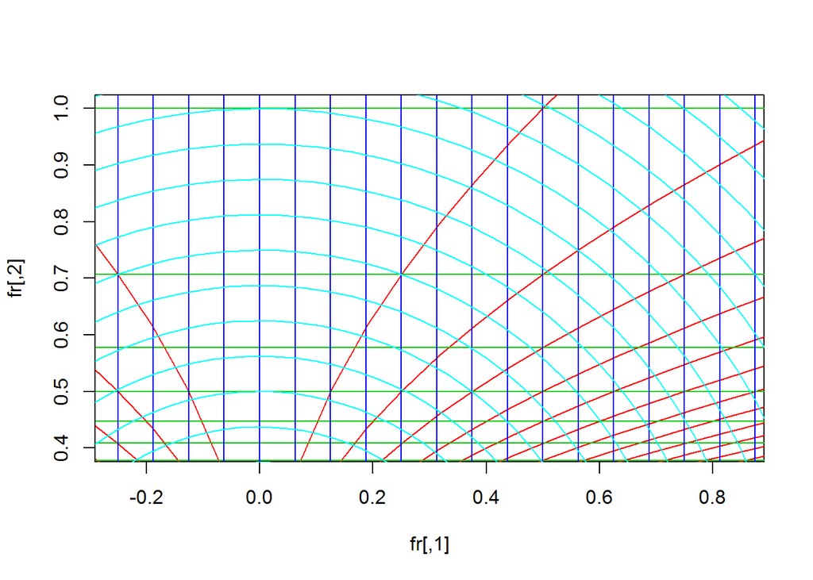

```r
# 正規分布、(m,s)座標に(theta1,theta2)格子
#
theta1 <- seq(from=1/2,to=1000,by=1/2)
theta2 <- -seq(from=1/2,to=1000,by=1/2)
eta1 <- seq(from=-1,to=1,by=1/(2^4))
eta2 <- seq(from=0,to=2,by=1/(2^4))

fr <- matrix(c(-0.5,0,0.5,0.5),byrow=TRUE,2,2)
plot(fr,asp=1,col=0,xlim=c(0,0.6),ylim=c(0.4,1))
t <- seq(from=0,to=1,length=100) * 2*pi

for(i in 1:length(theta1)){
  points(t,sqrt(t/theta1[i]),type="l",col=2)
  points(-t,sqrt(t/theta1[i]),type="l",col=2)
}

for(i in 1:length(theta2)){
    abline(h=sqrt(-1/(2*theta2[i])),col=3)
}
for(i in 1:length(eta1)){
    abline(v=eta1[i],col=4)
}
t <- seq(from=0,to=1,length=100) * 2*pi
for(i in 1:length(eta2)){
    points(eta2[i] * cos(t),eta2[i] * sin(t),type="l",col=5)
}
```

- 描かれた線はすべて「直線」である
- $\theta_1$一定の線(赤)と$\eta_2$一定の線(水色)は直交し、$\theta_2$一定の線(緑)と$\eta_1$一定の線(青)も直交している

# 2 Kullback-Leibler ダイバージェンス Kullback-Leibler divergence

## 2.1 曲がっているので距離は定まらない Due to non-flatness, no distance is difined

- 双対平坦ではあるが、単純に平坦ではないので、いわゆる距離は定められない。Although dually flat, the space of distributions is not “simply flat”. Therefore “distance” in a regular sense can not be defined.

## 2.2 ダイバージェンス Divergence

- ダイバージェンスと呼ばれる、距離と似た性質を持つものが定義できる。 Divergence that shares some features with distance can be defined.
- 双対平坦座標系にそのようなものを定めると、Kulback-Leibler divergence (KL divergence) となる。The divergence for dually flat coordinate systems is called Kullback-Leibler divergence (KL divergence).
- 2点 P,Qの確率分布がp,qであるとすると、PからQへのKLdは以下の式で表される。Assume two points P and Q, corresponding to distributions p and q, respectively. KLd from P to Q is expressed as;

$$KLd(P \to Q) = \int p \frac{\log{p}}{\log{q}} dx$$

- 式の非対称性からわかるように、QからPに変えると値が異なる。The formula is asymmetric, that means the exchange of P and Q changes the value of divergence.

## 2.3 例 Example

- ２つの正規分布P(m=0.4,s=0.4)とQ(m=0.6,0.8)を考える。 Assume two normal distributions P(m=0.4,s=0.4) and Q(m=0.6,0.8).

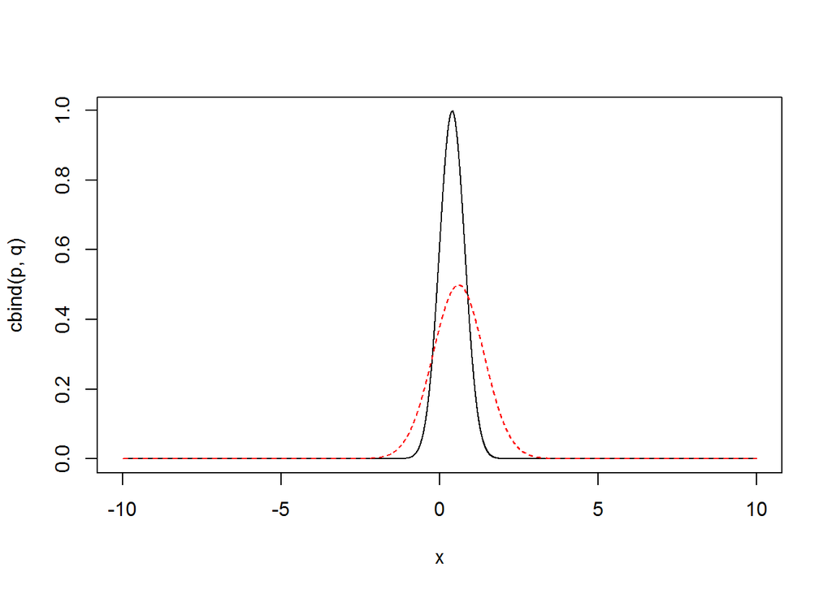

```r
x <- seq(from=-10,to=10,length=10^4)
p <- dnorm(x,0.4,0.4)
q <- dnorm(x,0.6,0.8)

matplot(x,cbind(p,q),type="l")
```

- KLd の計算 Calculation of KLd.

```r
KLdPQ <- sum(p*(log(p)-log(q))) * (x[2]-x[1])
KLdQP <- sum(q*(log(q)-log(p))) * (x[2]-x[1])
KLdPQ
```

```
## [1] 0.3493972
```

```r
KLdQP
```

```
## [1] 0.9318528
```

## 2.4 正規分布の２次元の広がり Draw normal distributions in 2d space.

$$\theta_1 = \frac{m}{s^2}\\
\theta_2 = -\frac{1}{2s^2}\\
m = -\frac{\theta_1}{2\theta_2}\\
s^2 = -\frac{1}{2\theta_2}$$

$$\eta_1 = m\\
\eta_2 = m^2+s^2\\
m = \eta_1\\
s^2 = \eta_2- \eta_1^2$$

- 点$P =(m_p=0.4,s_p=0.4)$を取る Point $P =(m_p=0.4,s_p=0.4)$ .

$$\theta_p1 = \frac{m_p}{s_p^2} = \frac{0.4}{0.16}=2.5\\
\theta_p2 = -\frac{1}{2 \times s_p^2} = -\frac{1}{2\times 0.16}\\
\eta_p1 = m_p = 0.4\\
\eta_p2 = m_p^2 + s_p^2 = 0.32$$

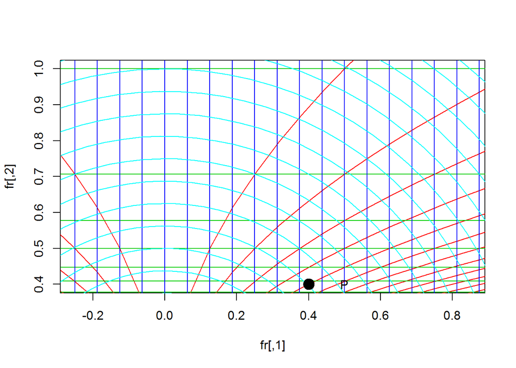

```r
# 正規分布、(m,s)座標に(theta1,theta2)格子
#
theta1 <- seq(from=1/2,to=1000,by=1/2)
theta2 <- -seq(from=1/2,to=1000,by=1/2)
eta1 <- seq(from=-1,to=1,by=1/(2^4))
eta2 <- seq(from=0,to=2,by=1/(2^4))

fr <- matrix(c(-0.5,0,0.5,0.5),byrow=TRUE,2,2)
plot(fr,asp=1,col=0,xlim=c(0,0.6),ylim=c(0.4,1))
t <- seq(from=0,to=1,length=100) * 2*pi

for(i in 1:length(theta1)){
  points(t,sqrt(t/theta1[i]),type="l",col=2)
  points(-t,sqrt(t/theta1[i]),type="l",col=2)

}

for(i in 1:length(theta2)){
    abline(h=sqrt(-1/(2*theta2[i])),col=3)
}
for(i in 1:length(eta1)){
    abline(v=eta1[i],col=4)
}
t <- seq(from=0,to=1,length=100) * 2*pi
for(i in 1:length(eta2)){
    points(eta2[i] * cos(t),eta2[i] * sin(t),type="l",col=5)
}

P.ms <- c(0.4,0.4)
P.theta <- my.ms2theta(P.ms[1],P.ms[2])
points(P.ms[1],P.ms[2],pch=20,cex=3)
text(P.ms[1]+0.1,P.ms[2],"P")
```

- 第２点$Q =(m_p=0.6,s_p=0.8)$を取る The 2nd point $Q =(m_p=0.6,s_p=0.8)$
  $$\theta_q1 = \frac{m_q}{s_q^2} = \frac{0.6}{0.64}=0.9375\\
  \theta_q2 = -\frac{1}{2\times s_q^2} = -\frac{1}{2 \times 0.64}\\
  \eta_q1 = m_p = 0.6\\
  \eta_q2 = m_p^2 + s_p^2 = 1$$

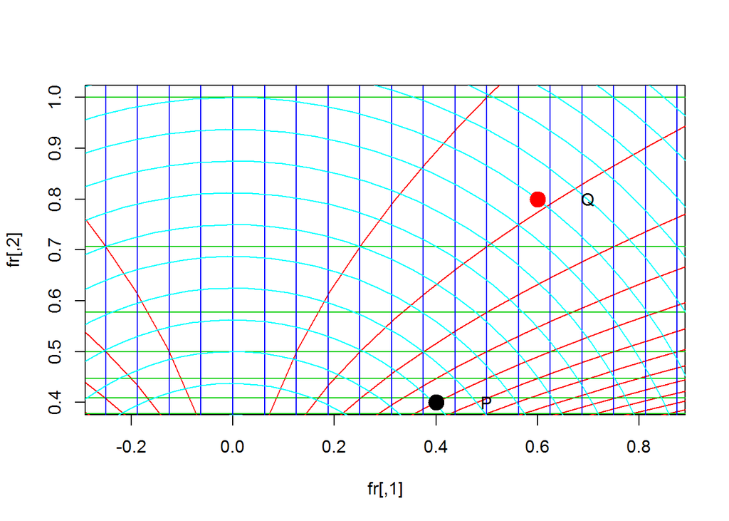

```r
fr <- matrix(c(-0.5,0,0.5,0.5),byrow=TRUE,2,2)
plot(fr,asp=1,col=0,xlim=c(0,0.6),ylim=c(0.4,1))
t <- seq(from=0,to=1,length=100) * 2*pi

for(i in 1:length(theta1)){
  points(t,sqrt(t/theta1[i]),type="l",col=2)
  points(-t,sqrt(t/theta1[i]),type="l",col=2)

}

for(i in 1:length(theta2)){
    abline(h=sqrt(-1/(2*theta2[i])),col=3)
}
for(i in 1:length(eta1)){
    abline(v=eta1[i],col=4)
}
t <- seq(from=0,to=1,length=100) * 2*pi
for(i in 1:length(eta2)){
    points(eta2[i] * cos(t),eta2[i] * sin(t),type="l",col=5)
}

P.ms <- c(0.4,0.4)
points(P.ms[1],P.ms[2],pch=20,cex=3)
text(P.ms[1]+0.1,P.ms[2],"P")
Q.ms <- c(0.6,0.8)
points(Q.ms[1],Q.ms[2],pch=20,cex=3,col=2)
text(Q.ms[1]+0.1,Q.ms[2],"Q")
```

- 点Pから点Qへと向かうにあたり、$\theta_1$が一定(赤)か$\theta_2$(緑)が一定か、$\eta_1$(青)が一定か$\eta_2$(水色)が一定な『直線』に沿って進むことにする。Assume you move from P to Q. You take a path on which $\theta_1$ or $\theta_2$ or $\eta_1$ or $\eta_2$ is constant, which is red, green, blue or light blue. This means you move “straight”.
- このとき、$\theta_1$一定の線(赤)と$\eta_2$一定の線(水色)は直交しているから、そのどちらかが一定になるように進む方法と Because red lines and light blue lines ($\theta_1$ constant and $\eta_2$ constant) are perpendicular, you can move only using these.
- もう片方の直交ペア$\theta_2$一定の線(緑)と$\eta_1$一定の線(青)のみを使って進む方法の２つを考える。Another way is to use only greens and blues, that are $\theta_2$ constant or $\eta_1$ constant.
- この２通りの進み方だと、２点間を結ぶ線を斜辺とする「直角三角形」の直角を挟む２辺となるからこのようにする。そして、そのようにするのは、斜辺の長さの取り方として好都合であるからである。どのように好都合かは後述する。The reason why we take these combinations is because we want to have right-angled triangles that are used later.
- $\theta_1$, $\eta_2$の場合 Case of $\theta_1$ or $\eta_2$
- 太い黒い線に沿って「長方形」の２辺を取ると、片方は$\theta$座標系の直線、もう片方は$\eta$座標系の直線。Thick black lines make “rectangle”, the edges of which are straight in $\theta$ or $\eta$ coordinate systems.

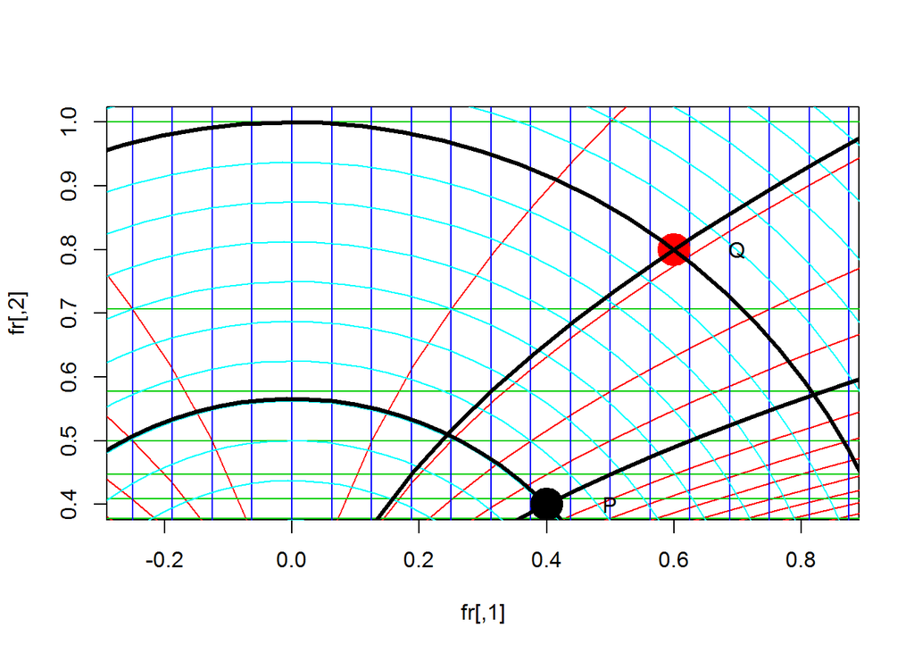

```r
fr <- matrix(c(-0.5,0,0.5,0.5),byrow=TRUE,2,2)
plot(fr,asp=1,col=0,xlim=c(0,0.6),ylim=c(0.4,1))
t <- seq(from=0,to=1,length=100) * 2*pi

for(i in 1:length(theta1)){
  points(t,sqrt(t/theta1[i]),type="l",col=2)
  points(-t,sqrt(t/theta1[i]),type="l",col=2)

}

for(i in 1:length(theta2)){
    abline(h=sqrt(-1/(2*theta2[i])),col=3)
}
for(i in 1:length(eta1)){
    abline(v=eta1[i],col=4)
}
t <- seq(from=0,to=1,length=100) * 2*pi
for(i in 1:length(eta2)){
    points(eta2[i] * cos(t),eta2[i] * sin(t),type="l",col=5)
}

P.ms <- c(0.4,0.4)
points(P.ms[1],P.ms[2],pch=20,cex=5)
text(P.ms[1]+0.1,P.ms[2],"P")
Q.ms <- c(0.6,0.8)
points(Q.ms[1],Q.ms[2],pch=20,cex=5,col=2)
text(Q.ms[1]+0.1,Q.ms[2],"Q")
P.thetas <- my.ms2theta(P.ms[1],P.ms[2])
P.etas <- my.ms2eta(P.ms[1],P.ms[2])
Q.thetas <- my.ms2theta(Q.ms[1],Q.ms[2])
Q.etas <- my.ms2eta(Q.ms[1],Q.ms[2])
points(t,sqrt(t/P.thetas[1]),type="l",col=1,lwd = 3)
points(t,sqrt(t/Q.thetas[1]),type="l",col=1,lwd = 3)

points(sqrt(P.etas[2]) * cos(t),sqrt(P.etas[2])* sin(t),type="l",col=1,lwd = 3)
points(sqrt(Q.etas[2]) * cos(t),sqrt(Q.etas[2])* sin(t),type="l",col=1,lwd = 3)
```

- 2本の直線の交点が2つある。$R_1,R_2$とすれば、その座標は Let $R_1$ and $R_2$ denote two crossing points.

$$R_1(\theta_1=\theta_1^P=2.5,\eta_2=\eta_2^Q = 1)\\
R_2(\theta_1 =\theta_1^Q = \frac{0.6}{0.64},\eta_2=\eta_2^P = 0.32)$$

- $\theta_1$と$\eta_2$とでできた座標なので、「混合座標」と呼ばれる。この2点の$m,s$を出しておこう。 Their coordinates can be expressed as mixture of $\theta$ and $\eta$; this is why these coordinates are called “mixture coordinates”.

```r
my.mix2ms12 <- function(theta1,eta2){
  s.sq <- (-1 + sqrt(1+4*theta1^2*eta2))/(2*theta1^2)
  s <- sqrt(s.sq)
  m <- theta1*s.sq
  return(c(m,s))
}
my.mix2ms21 <- function(eta1,theta2){
  m <- eta1
  s.sq <- -1/(2*theta2)
  s <- sqrt(s.sq)
  return(c(m,s))
}
R1.ms <- my.mix2ms12(P.thetas[1],Q.etas[2])
R2.ms <- my.mix2ms12(Q.thetas[1],P.etas[2])
R1.ms
```

```
## [1] 0.8198039 0.5726444
```

```r
R2.ms
```

```
## [1] 0.2441269 0.5102960
```

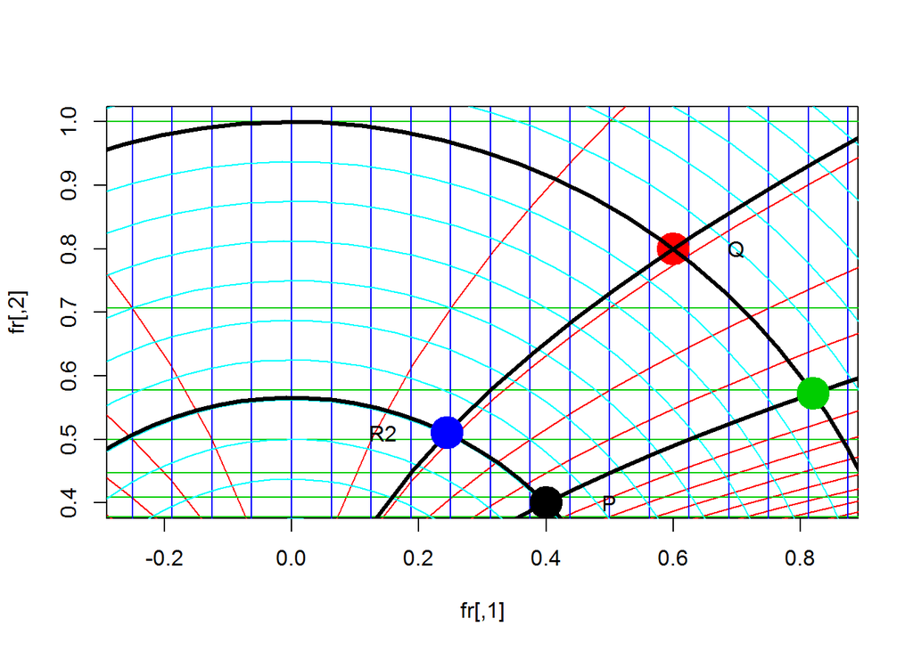

```r
fr <- matrix(c(-0.5,0,0.5,0.5),byrow=TRUE,2,2)
plot(fr,asp=1,col=0,xlim=c(0,0.6),ylim=c(0.4,1))
t <- seq(from=0,to=1,length=100) * 2*pi

for(i in 1:length(theta1)){
  points(t,sqrt(t/theta1[i]),type="l",col=2)
  points(-t,sqrt(t/theta1[i]),type="l",col=2)

}

for(i in 1:length(theta2)){
    abline(h=sqrt(-1/(2*theta2[i])),col=3)
}
for(i in 1:length(eta1)){
    abline(v=eta1[i],col=4)
}
t <- seq(from=0,to=1,length=100) * 2*pi
for(i in 1:length(eta2)){
    points(eta2[i] * cos(t),eta2[i] * sin(t),type="l",col=5)
}

P.ms <- c(0.4,0.4)
points(P.ms[1],P.ms[2],pch=20,cex=5)
text(P.ms[1]+0.1,P.ms[2],"P")
Q.ms <- c(0.6,0.8)
points(Q.ms[1],Q.ms[2],pch=20,cex=5,col=2)
text(Q.ms[1]+0.1,Q.ms[2],"Q")
P.thetas <- my.ms2theta(P.ms[1],P.ms[2])
P.etas <- my.ms2eta(P.ms[1],P.ms[2])
Q.thetas <- my.ms2theta(Q.ms[1],Q.ms[2])
Q.etas <- my.ms2eta(Q.ms[1],Q.ms[2])
points(t,sqrt(t/P.thetas[1]),type="l",col=1,lwd = 3)
points(t,sqrt(t/Q.thetas[1]),type="l",col=1,lwd = 3)

points(sqrt(P.etas[2]) * cos(t),sqrt(P.etas[2])* sin(t),type="l",col=1,lwd = 3)
points(sqrt(Q.etas[2]) * cos(t),sqrt(Q.etas[2])* sin(t),type="l",col=1,lwd = 3)

points(R1.ms[1],R1.ms[2],pch=20,cex=5,col=3)
points(R2.ms[1],R2.ms[2],pch=20,cex=5,col=4)
text(R1.ms[1]+0.1,R1.ms[2],"R1")
text(R2.ms[1]-0.1,R2.ms[2],"R2")
```

- $\theta_2$, $\eta_1$の場合 Another case with $\theta_2$ or $\eta_1$.

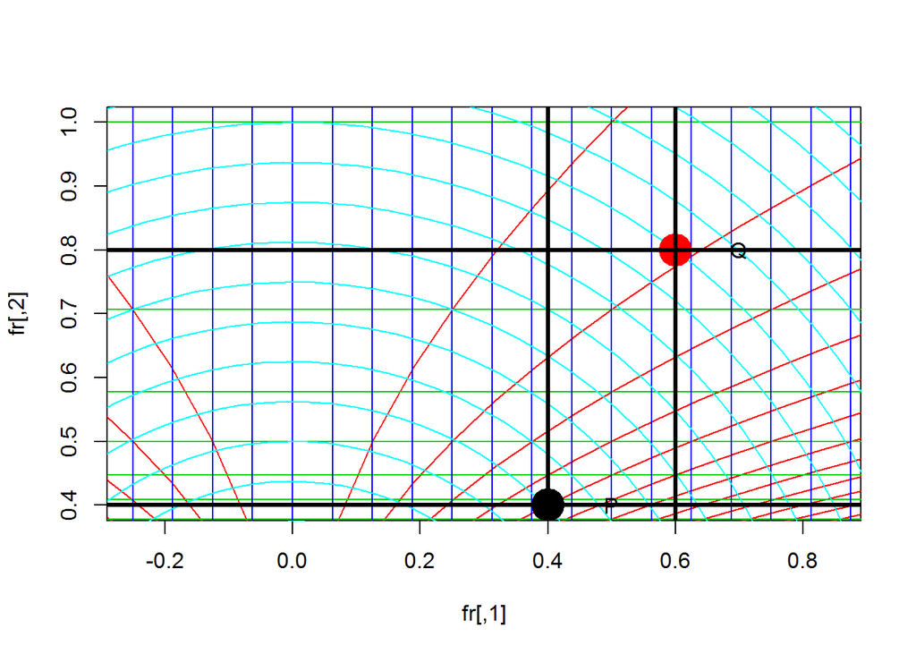

```r
fr <- matrix(c(-0.5,0,0.5,0.5),byrow=TRUE,2,2)
plot(fr,asp=1,col=0,xlim=c(0,0.6),ylim=c(0.4,1))
t <- seq(from=0,to=1,length=100) * 2*pi

for(i in 1:length(theta1)){
  points(t,sqrt(t/theta1[i]),type="l",col=2)
  points(-t,sqrt(t/theta1[i]),type="l",col=2)

}

for(i in 1:length(theta2)){
    abline(h=sqrt(-1/(2*theta2[i])),col=3)
}
for(i in 1:length(eta1)){
    abline(v=eta1[i],col=4)
}
t <- seq(from=0,to=1,length=100) * 2*pi
for(i in 1:length(eta2)){
    points(eta2[i] * cos(t),eta2[i] * sin(t),type="l",col=5)
}

P.ms <- c(0.4,0.4)
points(P.ms[1],P.ms[2],pch=20,cex=5)
text(P.ms[1]+0.1,P.ms[2],"P")
Q.ms <- c(0.6,0.8)
points(Q.ms[1],Q.ms[2],pch=20,cex=5,col=2)
text(Q.ms[1]+0.1,Q.ms[2],"Q")
P.thetas <- my.ms2theta(P.ms[1],P.ms[2])
P.etas <- my.ms2eta(P.ms[1],P.ms[2])
Q.thetas <- my.ms2theta(Q.ms[1],Q.ms[2])
Q.etas <- my.ms2eta(Q.ms[1],Q.ms[2])
abline(h=sqrt(-1/(2*P.thetas[2])),col=1,lwd=3)
abline(h=sqrt(-1/(2*Q.thetas[2])),col=1,lwd=3)

abline(v=P.etas[1],col=1,lwd=3)
abline(v=Q.etas[1],col=1,lwd=3)
```

- 2本の直線の交点が2つある。$R_3,R_4$とすれば、その座標は Let $R_3,R_4$ denote the crossing points.

$$R_3(\eta_1=\eta_1^P=0.4,\theta_2=\theta_2^Q = -\frac{1}{2\times0.64})\\
R_4(\eta_1 =\eta_1^Q = 0.6,\theta_2=\theta_2^P = -\frac{1}{2\times 0.16})$$

- $\theta_2$と$\eta_1$とでできた座標なので、これも「混合座標」と呼ばれる。この2点の$m,s$を出しておこう。 Again they are mixture.

```r
R3.ms <- my.mix2ms21(P.etas[1],Q.thetas[2])
R4.ms <- my.mix2ms21(Q.etas[1],P.thetas[2])
R3.ms
```

```
## [1] 0.4 0.8
```

```r
R4.ms
```

```
## [1] 0.6 0.4
```

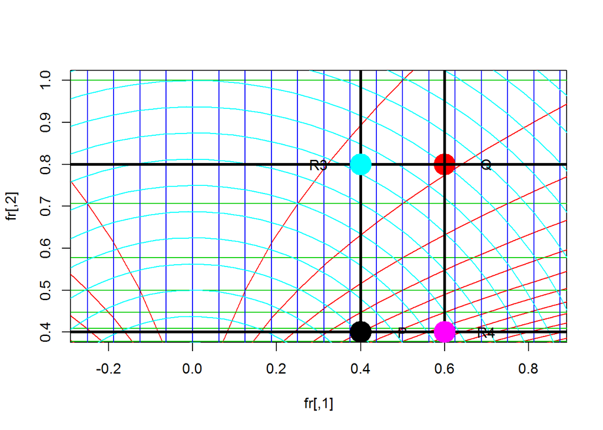

```r
fr <- matrix(c(-0.5,0,0.5,0.5),byrow=TRUE,2,2)
plot(fr,asp=1,col=0,xlim=c(0,0.6),ylim=c(0.4,1))
t <- seq(from=0,to=1,length=100) * 2*pi

for(i in 1:length(theta1)){
  points(t,sqrt(t/theta1[i]),type="l",col=2)
  points(-t,sqrt(t/theta1[i]),type="l",col=2)

}

for(i in 1:length(theta2)){
    abline(h=sqrt(-1/(2*theta2[i])),col=3)
}
for(i in 1:length(eta1)){
    abline(v=eta1[i],col=4)
}
t <- seq(from=0,to=1,length=100) * 2*pi
for(i in 1:length(eta2)){
    points(eta2[i] * cos(t),eta2[i] * sin(t),type="l",col=5)
}

P.ms <- c(0.4,0.4)
points(P.ms[1],P.ms[2],pch=20,cex=5)
text(P.ms[1]+0.1,P.ms[2],"P")
Q.ms <- c(0.6,0.8)
points(Q.ms[1],Q.ms[2],pch=20,cex=5,col=2)
text(Q.ms[1]+0.1,Q.ms[2],"Q")
P.thetas <- my.ms2theta(P.ms[1],P.ms[2])
P.etas <- my.ms2eta(P.ms[1],P.ms[2])
Q.thetas <- my.ms2theta(Q.ms[1],Q.ms[2])
Q.etas <- my.ms2eta(Q.ms[1],Q.ms[2])
abline(h=sqrt(-1/(2*P.thetas[2])),col=1,lwd=3)
abline(h=sqrt(-1/(2*Q.thetas[2])),col=1,lwd=3)

abline(v=P.etas[1],col=1,lwd=3)
abline(v=Q.etas[1],col=1,lwd=3)

points(R3.ms[1],R3.ms[2],pch=20,cex=5,col=5)
points(R4.ms[1],R4.ms[2],pch=20,cex=5,col=6)
text(R3.ms[1]-0.1,R3.ms[2],"R3")
text(R4.ms[1]+0.1,P.ms[2],"R4")
```

- $\theta_1$,$\eta_2$のペアでの「長方形」も$\theta_2$,$\eta_1$のペアでの「長方形」も、次の意味で「同じ」である。The 1st pair $\theta_1,\eta_2$ generated a rectangle and $\theta_2,\eta_1$ pair also generated a rectangle.

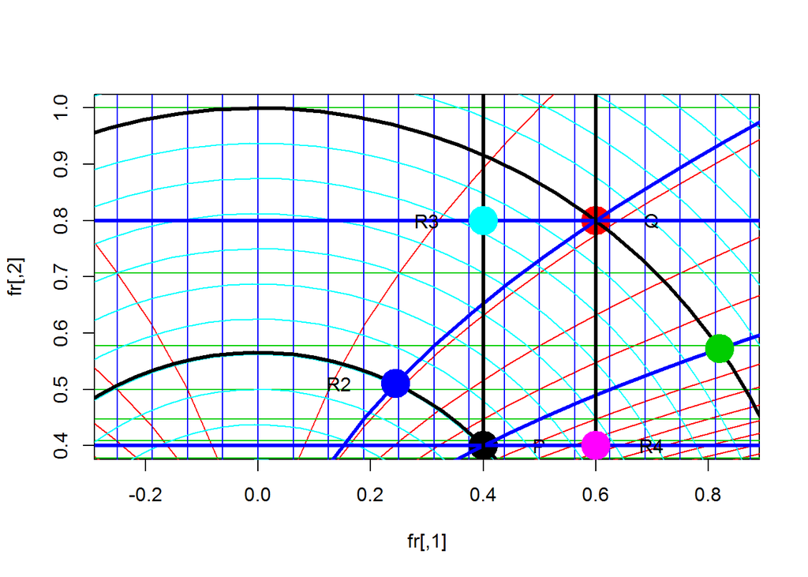

```r
fr <- matrix(c(-0.5,0,0.5,0.5),byrow=TRUE,2,2)
plot(fr,asp=1,col=0,xlim=c(0,0.6),ylim=c(0.4,1))
t <- seq(from=0,to=1,length=100) * 2*pi

for(i in 1:length(theta1)){
  points(t,sqrt(t/theta1[i]),type="l",col=2)
  points(-t,sqrt(t/theta1[i]),type="l",col=2)

}

for(i in 1:length(theta2)){
    abline(h=sqrt(-1/(2*theta2[i])),col=3)
}
for(i in 1:length(eta1)){
    abline(v=eta1[i],col=4)
}
t <- seq(from=0,to=1,length=100) * 2*pi
for(i in 1:length(eta2)){
    points(eta2[i] * cos(t),eta2[i] * sin(t),type="l",col=5)
}

P.ms <- c(0.4,0.4)
points(P.ms[1],P.ms[2],pch=20,cex=5)
text(P.ms[1]+0.1,P.ms[2],"P")
Q.ms <- c(0.6,0.8)
points(Q.ms[1],Q.ms[2],pch=20,cex=5,col=2)
text(Q.ms[1]+0.1,Q.ms[2],"Q")
P.thetas <- my.ms2theta(P.ms[1],P.ms[2])
P.etas <- my.ms2eta(P.ms[1],P.ms[2])
Q.thetas <- my.ms2theta(Q.ms[1],Q.ms[2])
Q.etas <- my.ms2eta(Q.ms[1],Q.ms[2])
points(t,sqrt(t/P.thetas[1]),type="l",col=4,lwd = 3)
points(t,sqrt(t/Q.thetas[1]),type="l",col=4,lwd = 3)

points(sqrt(P.etas[2]) * cos(t),sqrt(P.etas[2])* sin(t),type="l",col=1,lwd = 3)
points(sqrt(Q.etas[2]) * cos(t),sqrt(Q.etas[2])* sin(t),type="l",col=1,lwd = 3)


abline(h=sqrt(-1/(2*P.thetas[2])),col=4,lwd=3)
abline(h=sqrt(-1/(2*Q.thetas[2])),col=4,lwd=3)

abline(v=P.etas[1],col=1,lwd=3)
abline(v=Q.etas[1],col=1,lwd=3)

points(R1.ms[1],R1.ms[2],pch=20,cex=5,col=3)
points(R2.ms[1],R2.ms[2],pch=20,cex=5,col=4)
points(R3.ms[1],R3.ms[2],pch=20,cex=5,col=5)
points(R4.ms[1],R4.ms[2],pch=20,cex=5,col=6)
text(R1.ms[1]+0.1,R1.ms[2],"R1")
text(R2.ms[1]-0.1,R2.ms[2],"R2")
text(R3.ms[1]-0.1,R3.ms[2],"R3")
text(R4.ms[1]+0.1,R4.ms[2],"R4")
```

## 2.5 ２点間のダイバージェンス Divergence between two points.

- ２点間の距離のようなものであるダイバージェンスを考える。２点間に直線のようなものを取って、その長さが知りたい。Divergence that something like asquared distance is introduced as a measure between two points. Distance is a measure along straight lines and divergence should be also defined along “straight lines”.
- 距離の二乗に相当する量である。Divergence is like square of distance.
- この空間には、$\theta$座標系での直線も引けるし、$\eta$座標系での直線も引ける。We have two kinds of straight lines in $\theta$ and $\eta$ coordinates systems.
- それぞれの座標系の直線は、線形に表せるから、２点$P=(\theta_1^P,\theta_2^P)$と$Q=(\theta_1^Q,\theta_2^Q)$との間の$\theta$座標系な直線は以下のように表せる。Straignt lines are expressed as linear sum of each coordinates and the coordinates of lines in $\theta$ system are:

$$(\theta_1,\theta_2) = (\theta_1^P,\theta_2^P) + t (\theta_1^Q-\theta_1^P, \theta_2^Q-\theta_2^P)$$

- また、$\eta$座標系の直線は次のように表せる。Same for straight lines in $\eta$ system.

$$(\eta_1,\eta_2) = (\eta_1^P,\eta_2^P) + t (\eta_1^Q-\eta_1^P, \eta_2^Q-\eta_2^P)$$

- 二通りの「直線」を描く(青太線、赤破線)。Two straight lines are drawn with thick blue line and red broken line, which are ovelapped.

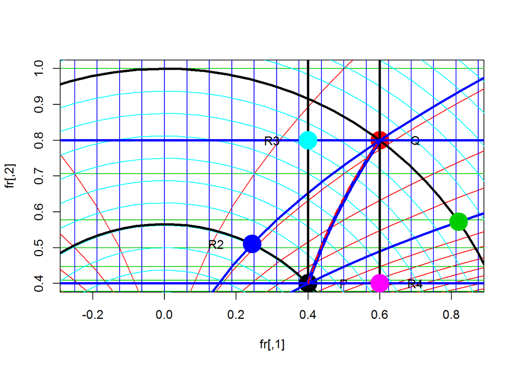

```r
fr <- matrix(c(-0.5,0,0.5,0.5),byrow=TRUE,2,2)
plot(fr,asp=1,col=0,xlim=c(0,0.6),ylim=c(0.4,1))
t <- seq(from=0,to=1,length=100) * 2*pi

for(i in 1:length(theta1)){
  points(t,sqrt(t/theta1[i]),type="l",col=2)
  points(-t,sqrt(t/theta1[i]),type="l",col=2)

}

for(i in 1:length(theta2)){
    abline(h=sqrt(-1/(2*theta2[i])),col=3)
}
for(i in 1:length(eta1)){
    abline(v=eta1[i],col=4)
}
t <- seq(from=0,to=1,length=100) * 2*pi
for(i in 1:length(eta2)){
    points(eta2[i] * cos(t),eta2[i] * sin(t),type="l",col=5)
}

P.ms <- c(0.4,0.4)
points(P.ms[1],P.ms[2],pch=20,cex=5)
text(P.ms[1]+0.1,P.ms[2],"P")
Q.ms <- c(0.6,0.8)
points(Q.ms[1],Q.ms[2],pch=20,cex=5,col=2)
text(Q.ms[1]+0.1,Q.ms[2],"Q")
P.thetas <- my.ms2theta(P.ms[1],P.ms[2])
P.etas <- my.ms2eta(P.ms[1],P.ms[2])
Q.thetas <- my.ms2theta(Q.ms[1],Q.ms[2])
Q.etas <- my.ms2eta(Q.ms[1],Q.ms[2])
points(t,sqrt(t/P.thetas[1]),type="l",col=4,lwd = 3)
points(t,sqrt(t/Q.thetas[1]),type="l",col=4,lwd = 3)

points(sqrt(P.etas[2]) * cos(t),sqrt(P.etas[2])* sin(t),type="l",col=1,lwd = 3)
points(sqrt(Q.etas[2]) * cos(t),sqrt(Q.etas[2])* sin(t),type="l",col=1,lwd = 3)


abline(h=sqrt(-1/(2*P.thetas[2])),col=4,lwd=3)
abline(h=sqrt(-1/(2*Q.thetas[2])),col=4,lwd=3)

abline(v=P.etas[1],col=1,lwd=3)
abline(v=Q.etas[1],col=1,lwd=3)

points(R1.ms[1],R1.ms[2],pch=20,cex=5,col=3)
points(R2.ms[1],R2.ms[2],pch=20,cex=5,col=4)
points(R3.ms[1],R3.ms[2],pch=20,cex=5,col=5)
points(R4.ms[1],R4.ms[2],pch=20,cex=5,col=6)
text(R1.ms[1]+0.1,R1.ms[2],"R1")
text(R2.ms[1]-0.1,R2.ms[2],"R2")
text(R3.ms[1]-0.1,R3.ms[2],"R3")
text(R4.ms[1]+0.1,R4.ms[2],"R4")

t <- seq(from=0,to=1,length=100)
line.theta1 <- P.thetas[1] + t * (Q.thetas[1]-P.thetas[1])
line.theta2 <- P.thetas[2] + t * (Q.thetas[2]-P.thetas[2])
line.eta1 <- P.etas[1] + t * (Q.etas[1]-P.etas[1])
line.eta2 <- P.etas[2] + t * (Q.etas[2]-P.etas[2])
line.theta.ms <- matrix(0,length(t),2)
line.eta.ms <- matrix(0,length(t),2)
for(i in 1:length(t)){
  line.theta.ms[i,] <- my.theta2ms(line.theta1[i],line.theta2[i])
  line.eta.ms[i,] <- my.eta2ms(line.eta1[i],line.eta2[i])
}
points(line.theta.ms[,1],line.theta.ms[,2],type="l",col=4,lwd=5)
points(line.eta.ms[,1],line.eta.ms[,2],type="l",col=2,lwd=2,lty=2)
```

## 2.6 二通りのダイバージェンスとKL divergence, Relation between KL divergence and two types of divergences

- ２点P,Qの間のダイバージェンスには、次のような２通りの値がある。PとQとを交換した形になっていて、“$P||Q$”の、もしくは“$Q||P$”のKL divergenceと呼ばれる。Between two points P and Q, two divergence values are defined. KL divergence with “$P||Q$” and “$Q||P$”.

$$KLd(P||Q)=\int p (\log(p)-\log(q))dx\\
KLd(Q||P) = \int q (\log(q)-\log(p))dx$$

- 情報幾何では、これに次のような４つの意味を持たせる。Information geometry interprets these two in four ways.
- $D^{\theta}(P\to Q)$:PからQへ、$\theta$的に($\alpha=1$的に)取ったダイバージェンス Divergence from P to Q in terms of $, or $=1.
- $D^{\eta}(P\to Q)$:PからQへ、$\eta$的に($\alpha=-1$的に)取ったダイバージェンス Divergence from P to Q in terms of $, or $=-1.
- $D^{\theta}(Q\to P)$:QからPへ、$\theta$的に($\alpha=1$的に)取ったダイバージェンス Divergence from Q to P in terms of $, or $=1.
- $D^{\eta}(Q\to P)$:QからPへ、$\eta$的に($\alpha=-1$的に)取ったダイバージェンス Divergence from Q to P in terms of $, or $=-1.
- これが、以下のような対応関係を持っている。See following relation among them.

$$D^{\eta}(P\to Q) = D^{\theta}(Q \to P) = KLd(P||Q)\\
D^{\theta}(P\to Q) = D^{\eta}(Q \to P) = KLd(Q||P)\\$$

- ダイバージェンスを計算してみる。Calculation of divergence values.

```r
my.divergence <- function(dP,dQ,dx,alpha=-1){
  if(alpha==-1){
    ret <- sum(dP * (log(dP)-log(dQ))) * dx
  }else{
    ret <- sum(dQ * (log(dQ)-log(dP))) * dx
  }
  return(ret)
}
x <- seq(from=-10,to=10,length=10^4)

dP <- dnorm(x,P.ms[1],P.ms[2])
dQ <- dnorm(x,Q.ms[1],Q.ms[2])

dx <- x[2]-x[1]
# P->Q alpha=1
my.divergence(dP,dQ,dx,alpha=1)
```

```
## [1] 0.9318528
```

```r
# P->Q alpha=-1
my.divergence(dP,dQ,dx,alpha=-1)
```

```
## [1] 0.3493972
```

```r
# Q->P alpha=1
my.divergence(dQ,dP,dx,alpha=1)
```

```
## [1] 0.3493972
```

```r
# Q->P alpha=-1
my.divergence(dQ,dP,dx,alpha=-1)
```

```
## [1] 0.9318528
```

## 2.7 拡張ピタゴラスの定理 Extended Pythagorean theorem

- $\theta$,$\eta$は双直交なので、ピタゴラスの定理のような性質が、上記のダイバージェンスには存在する。 Because $\theta$ and $\eta$ are dual orthogonal, divergeces for them have a feature related with Pythagorean theorem.
- ピタゴラスの定理は、直角三角形の３辺の長さに$a^2+b^2=c^2$という関係があることを言う。Pythagorean theorem shows relation among length of three edges of right-angled triangle, $a^2+b^2=c^2$.
- 双対座標系での拡張ピタゴラスの定理は次のような関係のことを言う。The extended Pythagorean theorem in dual coordinate systems is as follow.
- $P$と$R_i$とは$\theta$での「直線(測地線)」で結ばれ、$R_i$と$Q$とは$\eta$での「直線(測地線)」で結ばれているとき、以下の関係にある。具体的には、$R_1,R_4$がこれに相当する。Assume a point $R_i$ for P and Q, where $R_i$ should meet; the “straight”" line between P and $R_i$ is $\theta$’ geodesics and the “straight” line between Q and $R_i$ is $\eta$’s geodesics, for example $R_1$ and $R_4$, then;
  $$D^{\theta}(P\to Q) = D^{\theta}(P\to R_i) + D^{\theta}(R_i\to Q)\\$$

```r
dR1 <- dnorm(x,R1.ms[1],R1.ms[2])
dR2 <- dnorm(x,R2.ms[1],R2.ms[2])
dR3 <- dnorm(x,R3.ms[1],R3.ms[2])
dR4 <- dnorm(x,R4.ms[1],R4.ms[2])

my.divergence(dP,dQ,dx,alpha=1)
```

```
## [1] 0.9318528
```

```r
my.divergence(dP,dR1,dx,alpha=1) + my.divergence(dR1,dQ,dx,alpha=1)
```

```
## [1] 0.9318528
```

```r
my.divergence(dP,dR4,dx,alpha=1) + my.divergence(dR4,dQ,dx,alpha=1)
```

```
## [1] 0.9318528
```

- $P$と$R_i$とは$\eta$での「直線(測地線)」で結ばれ、$R_i$と$Q$とは$\theta$での「直線(測地線)」で結ばれているとき、以下の関係にある。具体的には、$R2,R3$がこれに相当する。Assume a point $R_i$ for P and Q, where $R_i$ should meet; the “straight”" line between P and $R_i$ is $\eta$’ geodesics and the “straight” line between Q and $R_i$ is $\theta$’s geodesics, for example $R_2$ and $R_3$, then;
  $$D^{\eta}(P\to Q) = D^{\eta}(P\to R_i) + D^{\eta}(R_1\to Q)\\$$

```r
my.divergence(dP,dQ,dx,alpha=-1)
```

```
## [1] 0.3493972
```

```r
my.divergence(dP,dR2,dx,alpha=-1) + my.divergence(dR2,dQ,dx,alpha=-1)
```

```
## [1] 0.3493972
```

```r
my.divergence(dP,dR3,dx,alpha=-1) + my.divergence(dR3,dQ,dx,alpha=-1)
```

```
## [1] 0.3493972
```

## 2.8 練習問題 Exercise

- PとQとを入れ替えて、拡張ピタゴラスの定理を確かめてみよ。Exchange P and Q and check the theorem.
- 上記で選ばれた$R_i$,$\alpha$の組み合わせと異なる組み合わせでは、拡張ピタゴラスの定理が成立しないことを確かめよ。Check the sum does not fit if you apply combinations of $R_i$ and $\alpha$ not mentioned above.

# 3 推定 Estimation

- 今、観測データが指し示す確率分布が点$P$に相当しているとする。Assume your data set indicates a distribution corresponding to a point P.
- モデルを考えていてそのモデルでは、$\eta_2=a$という固定値だとする。そのときに点Pから、$\eta_2=a$という部分空間への最短ダイバージェンスをとるとする。You want to apply a model where $\eta_2$ value is fixed at a value $a$. You want to fit your data set or $P$ to a subspace where $\eta_2=a$. You can draw a shortest path from $P$ to the subspace. The shortest path should have “shortest” divergence.
- そのような点は、$R_1$である。そのような点R1を探すにあたって、$\theta_1$が一定の直線に沿って探せばよい。In case of the expample shown above, the point to be estimated is $R_1$. You can reach to $R_1$ by taking a straight line of $\theta_1$ being constant.
- これは推定の情報幾何的解釈($\theta$,$\eta$座標系を用いた解釈)の一例である。This is an interpretation of estimation taski in information geometry world with $\theta$ and $\eta$ coordinate systems.